# DATA698 - ProjFinal

## Data 698 - Research Project

#### May 15, 2022

## OBJECTIVE

**2022 IS A WORLD CUP YEAR! (the cup is held every four years). In honor of this year’s cup, my project will focus on the other international soccer tournaments that are not quite as prestigious. There is something special about representing your country on the international scene. Only the very best players from each country get to experience that moment when you stand on the touchline, arm across your chest as your country’s national anthem fills your heart with pride.**

**You don’t need to be a soccer fan to know about the world cup, the biggest international soccer tournament in the world – Everyone loves the World Cup! But, have you ever heard of any of the regional tournaments? The African Cup of Nations! The Euros! Copa America!**

[figure not shown]

## BACKGROUND

**The governing body of soccer is called FIFA [Fédération Internationale de Football Associa- tion]. FIFA is comprised of six member Associations which represent different regions of the world. Each Confederation hosts a tournament open only to the countries that belong to that region/confederation.**

**1. CONCACAF (Confederation of North, Central America and Caribbean Association)** Hosts The Gold Cup every 2 years. The last tournament was in 2021 Participants: USA, Jamaica, Mexico, Canada, Honduras, Grenada, El Salvador, Costa Rica, Martinique, Suriname, Panama, Qatar (via special invite) , Trinidad, Haiti, Guadeloupe, Guatemala

**2. CAF (Confédération Africaine de Football)** Hosts The African Cup of Nations every 2 years. The last tournament concluded earlier this month (Feb 2022) with Senegal taking home the trophy. Participants: Cameroon, Senegal, Algeria, Mali, Tunisia, Burkina Faso, Guinea, Comoros, Gabon, Gambia, Egypt, Ghana, Equatorial guinea, Zimbabwe, Ivory Coast, Morocco, Nigeria, Sudan, Malawi, Ethiopia, Mauritania, Guinea-Bissau, Cape Verde, Sierra Leone

**3. UEFA (Union des associations européennes de football)** Hosts The Euros every 2 years. The last tournament was Euro 2020 but took place in 2021 due to the pandemic. Participants: Belgium, Italy, Russia, Poland, Ukraine, Spain, France, Turkey, England, Czech Republic, Finland, Sweden, Croatia, Austria, Netherlands, Germany, Portugal, Switzerland, Denmark, Wales, North Macedonia, Hungary, Slovakia, Scotland

**4. CONMEBOL (Confederación Sudamericana de Fútbol)** Hosts The Copa America. The tour- nament does not follow a consistent schedule like the others, it occurs every 1 - 4 years. The latest tournament was in 2021. Participants: Uruguay, Paraguay, Chile, Bolivia, Argentina, Ecuador, Peru, Venezuela, Ecuador, Colombia, Brazil

**5. AFC (Asian Football Confederation)** Hosts The Asian cup every 4 years, the latest tournament was in 2019. Participants: Japan, South Korea, Qatar, United Arab Emirates, Thailand, Saudi Arabia, Australia, Uzbekistan, Iran, Iraq, Syria, China PR, Palestine, Oman, India, Lebanon, Turkmenistan, Jordan, Bahrain, Vietnam, Kyrgyzstan, North Korea, Philippines, Yemen

**6. OFC (Oceania Football Confederation)** Hosts The OFC Nations Cup every 4 years, the lat- est tournament was supposed to take place in 2020 but was cancelled due to the pandemic. The next tournament will take place in 2024. Represents Countries such as New Zealand, Fiji, American Samoa Participants: Fiji, New Caledonia, New Zealand, Papua New Guinea, Solomon Islands, Tahiti, Vanuatu, Samoa

### PART 1 - Getting setup, import libraries and tools.

Twint will handle most of the heavy lifting of scraping twitter, the other tools will be used to present the data.

```python
#LOAD LIBRARIES

import tweepy
from textblob import TextBlob
import pandas as pd
import numpy as np
import re
import matplotlib.pyplot as plt
plt.style.use('fivethirtyeight')
from wordcloud import WordCloud
```

```python
# IMPORT TWINT TO DO THE SCRAPING
import twint
import nest_asyncio
nest_asyncio.apply()
#we need nest_asyncio to call async routines,similar as performing concurrent tasks.
```

### PART 2 - Gathering the tweets .

Tweets are gathered based on the duration of the tournament and the official hashtag.

```python
# GATHERING GOLD CUP 2021 TWEETS
c = twint.Config()
c.Search = '#GoldCup21'
c.Since = '2021-07-10'
c.Until = '2021-08-01'
c.Limit = '1000'
c.Lang = 'en'
c.Hide_output = True
c.Pandas = True
twint.run.Search(c)
goldcup_df = twint.storage.panda.Tweets_df #result is saved to df


# PREVIEW THE DATAFRAME
goldcup_df.head()
```

```
[!] No more data! Scraping will stop now.
found 0 deleted tweets in this search.
```

|  | id | conversation_id | created_at | date | timezone | place | tweet | language | hashtags | cashtags | ... | geo | source | user_rt_id | user_rt | retweet_id | reply_to | retweet_date | translate | trans_src | trans_dest |
| --- | --- | --- | --- | --- | --- | --- | --- | --- | --- | --- | --- | --- | --- | --- | --- | --- | --- | --- | --- | --- | --- |
| 0 | 1421258097549524997 | 1421258097549524997 | 1.627689e+12 | 2021-07-30 19:55:10 | -0400 |  | Serious question: will @Concacaf ever get to t... | en | [concacaf, goldcup, goldcup21] | [] | ... |  |  |  |  |  | [] |  |  |  |  |
| 1 | 1421255822294720513 | 1421255822294720513 | 1.627689e+12 | 2021-07-30 19:46:08 | -0400 |  | We'll have a strong contingent traveling to Ve... | en | [goldcup21, usavmex, usmnt, aohappyhour] | [] | ... |  |  |  |  |  | [] |  |  |  |  |
| 2 | 1421253814959497216 | 1421252285091483657 | 1.627688e+12 | 2021-07-30 19:38:09 | -0400 |  | @KennyOmegamanX @KennyOmegamanX you see the #G... | en | [goldcup21, mex, can] | [] | ... |  |  |  |  |  | [{'screen_name': 'KennyOmegamanX', 'name': 'Ke... |  |  |  |  |
| 3 | 1421250736499961865 | 1421250736499961865 | 1.627688e+12 | 2021-07-30 19:25:55 | -0400 |  | ÉTATS-UNIS - MEXIQUE... le grand classique nor... | fr | [goldcup21] | [] | ... |  |  |  |  |  | [] |  |  |  |  |
| 4 | 1421247659122339849 | 1421247659122339849 | 1.627687e+12 | 2021-07-30 19:13:42 | -0400 |  | @adamjones985 tune into the #GoldCup21 final S... | en | [goldcup21] | [] | ... |  |  |  |  |  | [] |  |  |  |  |

5 rows × 38 columns

```python
# GATHERING ALL THE OTHER TOURNAMENTS AS WELL.

# GATHERING EURO 2020 TWEETS
c = twint.Config()
c.Search = '#euro2020'
c.Since = '2020-06-01'
c.Until = '2021-07-11'
c.Limit = '1000'
c.Lang = 'en'
c.Hide_output = True
c.Pandas = True
twint.run.Search(c)
eurocup_df = twint.storage.panda.Tweets_df #result is saved to df
```

```
[!] No more data! Scraping will stop now.
found 0 deleted tweets in this search.
```

```python
# GATHERING AFCON CUP 2021 TWEETS
c = twint.Config()
c.Search = '#afcon21'
c.Since = '2021-01-09'
c.Until = '2022-02-06'
c.Limit = '1000'
c.Lang = 'en'
c.Hide_output = True
c.Pandas = True
twint.run.Search(c)
afconcup_df = twint.storage.panda.Tweets_df #result is saved to df
```

```
[!] No more data! Scraping will stop now.
found 0 deleted tweets in this search.
```

```python
# GATHERING COPA AMERICA TWEETS
c = twint.Config()
c.Search = '#copaamerica'
c.Since = '2018-06-07'
c.Until = '2020-07-07'
c.Limit = '1000'
c.Lang = 'en'
c.Hide_output = True
c.Pandas = True
twint.run.Search(c)
copaamerica_df = twint.storage.panda.Tweets_df #result is saved to df
```

```
[!] No more data! Scraping will stop now.
found 0 deleted tweets in this search.
```

```python
# GATHERING OFC NATIONS CUP 2016 TWEETS
c = twint.Config()
c.Search = '#OFCNationsCup2016'
c.Since = '2015-05-28'
c.Until = '2017-06-11'
c.Limit = '1000'
c.Lang = 'en'
c.Hide_output = True
c.Pandas = True
twint.run.Search(c)
ofccup_df = twint.storage.panda.Tweets_df #result is saved to df
```

```
[!] No more data! Scraping will stop now.
found 0 deleted tweets in this search.
```

```python
# GATHERING ASIAN CUP 2019 TWEETS
c = twint.Config()
c.Search = '#AsianCup2019'
c.Since = '2018-01-05'
c.Until = '2019-02-01'
c.Limit = '1000'
c.Lang = 'en'
c.Hide_output = True
c.Pandas = True
twint.run.Search(c)
asiancup_df = twint.storage.panda.Tweets_df #result is saved to df
```

```
[!] No more data! Scraping will stop now.
found 0 deleted tweets in this search.
```

### PART 3 - Cleaning the tweets .

Tweets are loaded with Metadata, links, punctuations and media which i'm not interested in.

```python
# CREATE A DATAFRAME WITH SINGLE COLUMN CALLED TWEETS SINCE WE ARE ONLY INTERESTED IN THE TWEETS AND NONE OF THE METADATA.
goldcup_df = goldcup_df[['tweet']].copy()
eurocup_df = eurocup_df[['tweet']].copy()
afconcup_df = afconcup_df[['tweet']].copy()
ofccup_df = ofccup_df[['tweet']].copy()
copaamerica_df = copaamerica_df[['tweet']].copy()
asiancup_df = asiancup_df[['tweet']].copy()

goldcup_df.head() #PREVIEW THE NEW DATAFRAME
```

|  | tweet |
| --- | --- |
| 0 | Serious question: will @Concacaf ever get to t... |
| 1 | We'll have a strong contingent traveling to Ve... |
| 2 | @KennyOmegamanX @KennyOmegamanX you see the #G... |
| 3 | ÉTATS-UNIS - MEXIQUE... le grand classique nor... |
| 4 | @adamjones985 tune into the #GoldCup21 final S... |

```python
# CREATING A FUNCTION TO CLEAN THE TWEETS

def cleanTxt(text):
    text = re.sub(r'@[A-Za-z0-9]+', '', text) #Remove mentions
    text = re.sub(r'#', '', text) #Remove the '#' symbol
    text = re.sub(r'RT[\s]+', '', text) #Remove RT
    text = re.sub(r'https?:\/\/\S+', '', text) #Remove the hyper links

    return text

# Cleaning the text
goldcup_df['tweet']= goldcup_df['tweet'].apply(cleanTxt)
eurocup_df['tweet']= eurocup_df['tweet'].apply(cleanTxt)
afconcup_df['tweet']= afconcup_df['tweet'].apply(cleanTxt)
copaamerica_df['tweet']= copaamerica_df['tweet'].apply(cleanTxt)
asiancup_df['tweet']= asiancup_df['tweet'].apply(cleanTxt)
ofccup_df['tweet']= ofccup_df['tweet'].apply(cleanTxt)

# Show cleaned text
afconcup_df
```

|  | tweet |
| --- | --- |
| 0 | 🔜 Senegal v Mısır finalini AFCON21 Yayınlayac... |
| 1 | Gabaski the mountain 🏔️afcon Egypt AFCON21 Fo... |
| 2 | Who wins the AFCON21 😊 |
| 3 | From now till Sunday, I rep 🇸🇳. I am from Daka... |
| 4 | It seems as if we do not appreciate Serero eno... |
| 5 | Since 2020, Edouard Mendy has reached finals i... |
| 6 | 🇨🇲 AFCON21 Third Place 🗓️ 5 Feb 20:00 WAT 🏟️ ... |
| 7 | Broda, tu as tout le talent pour être l’un de... |
| 8 | AFCON21 final this Sunday 6th February 2022 ..... |
| 9 | Le grand moment approche ! À l'Ambassade de Gr... |
| 10 | Thank you papa Eto.o...You are a true leader..... |
| 11 | Please give us the big show mo 🇪🇬💪🏹 AFCON21 Li... |
| 12 | Finale AFCON21 TeamSenegal vs TeamEgypt Tot... |
| 13 | 💪 Amis de toujours, rivaux d'un soir. 🇸🇳 Sadi... |
| 14 | 💪 Vrienden voor het leven, rivalen voor één av... |
| 15 | Si DavidEtoo ne sortait pas le song là, on all... |
| 16 | 10 players who could have played in the AFCON ... |

### PART 3 - Visualizing the tweets via wordcloud

The bigger and bolder the word appears, the more often it's mentioned within the collection of tweets and the more important it is.

```
<function matplotlib.pyplot.show(close=None, block=None)>
```

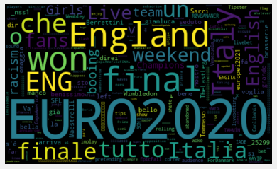

```python
# PLOT THE EURO CUP WORD CLOUD
allWords = '  '.join( [twts for twts in eurocup_df['tweet']])
wordCloud = WordCloud(width = 500, height = 300, random_state = 21, max_font_size = 119).generate(allWords)

plt.imshow(wordCloud, interpolation = "bilinear")
plt.axis('off')
plt.show
```

The Wordcloud seems to tell the story of the finals of the tournament which was contested between England and Italy. Italy won on penalties in the end, English players who missed their penalty kicks were subjected to racist attacks on social media. The sentiment appears mostly neutral and positive, but there's some negativity as well in the form of 'booing' and'racism'.

```
<function matplotlib.pyplot.show(close=None, block=None)>
```

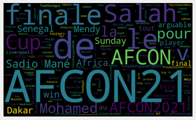

```python
# PLOT THE AFRICAN CUP WORD CLOUD
allWords = '  '.join( [twts for twts in afconcup_df['tweet']])
wordCloud = WordCloud(width = 500, height = 300, random_state = 21, max_font_size = 119).generate(allWords)

plt.imshow(wordCloud, interpolation = "bilinear")
plt.axis('off')
plt.show
```

The Worldcloud reflects alot of excitement about the final of the tournament. It captures the storyline of Mane and Salah who are teammates at the club level with Liverpool but they will now face each other in this the final of the African Cup! Also Salah is arguably the best player in the world at the moment, thats why his name is as large as it is.

```
<function matplotlib.pyplot.show(close=None, block=None)>
```

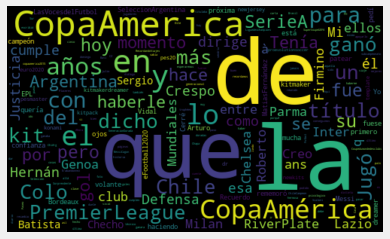

```python
# PLOT THE COPA AMERICA WORD CLOUD
allWords = '  '.join( [twts for twts in copaamerica_df['tweet']])
wordCloud = WordCloud(width = 500, height = 300, random_state = 21, max_font_size = 119).generate(allWords)

plt.imshow(wordCloud, interpolation = "bilinear")
plt.axis('off')
plt.show
```

Most of the words on this Wordcloud are spanish as expected since this is the South American Cup popularly known as Copa America! The sentiment seems very positive , its focused on star south american players that play around the world and tournament favourites Argentina.

```
<function matplotlib.pyplot.show(close=None, block=None)>
```

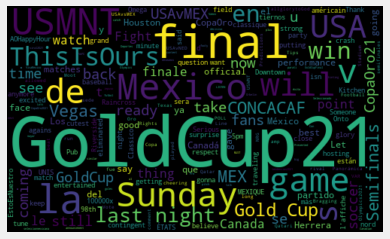

```python
# PLOT THE GOLD CUP WORD CLOUD
allWords = '  '.join( [twts for twts in goldcup_df['tweet']])
wordCloud = WordCloud(width = 500, height = 300, random_state = 21, max_font_size = 119).generate(allWords)

plt.imshow(wordCloud, interpolation = "bilinear")
plt.axis('off')
plt.show
```

The dominant sentiments here seem neutral and positive. The rivalry between the two biggest teams in the division is popular; USA and Mexico. Also they are the two teams in the final of tournament. The USA goes on to win the cup with a young team. There is also some negativity but very little - hardly visible on the Wordcloud

```
<function matplotlib.pyplot.show(close=None, block=None)>
```

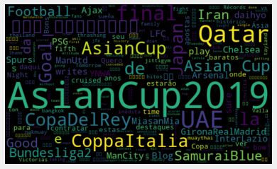

```python
# PLOT THE ASIAN CUP WORD CLOUD
allWords = '  '.join( [twts for twts in asiancup_df['tweet']])
wordCloud = WordCloud(width = 500, height = 300, random_state = 21, max_font_size = 119).generate(allWords)

plt.imshow(wordCloud, interpolation = "bilinear")
plt.axis('off')
plt.show
```

Another positive word cloud that captures the quality of the players participating in the tournament; many of the giant european soccer clubs are mentioned such as Chelsea, Man City and Real Madrid . Qatar, Iran and UAE are some of the favourite teams to win.

```
<function matplotlib.pyplot.show(close=None, block=None)>
```

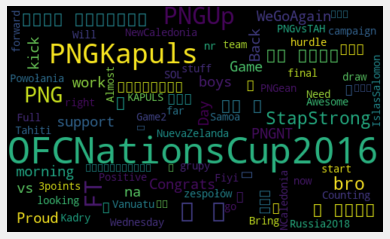

```python
# PLOT THE OCEANIA CUP WORD CLOUD
allWords = '  '.join( [twts for twts in ofccup_df['tweet']])
wordCloud = WordCloud(width = 500, height = 300, random_state = 21, max_font_size = 119).generate(allWords)

plt.imshow(wordCloud, interpolation = "bilinear")
plt.axis('off')
plt.show
```

'Proud' 'support' 'awesome' are a few of the words in the cloud that contribute to the overall positive sentiment. PNG or Papua New Guinea had a cinderella run all the way to the finals of the tournament where they lost on penalties to tournament favourites New Zealand. The Wordcloud captures the support PNG had along the way.